# Analysis - Metadata

Tom Offrede

2023-04-20

# Summary of results

- People found the room warmer at the end of the experiment in the *close* condition (already accounting for real room temperature).
- People in the *close* condition felt *closer* to their partners and *liked* them more.
- There was a positive correlation between all the variables referring to their perception of their partner (closeness, similarity, how much they liked them, how much they wanted to be friends).
  - But I’m not sure about principal components…

# Descriptives

## Gender

2 male dyads, 17 female dyads, 38 people total

```r
table(m$gender)
```

```
##
## Female   Male
##     34      4
```

## Age

```r
table(m$age)
```

```
##
## 18 19 20 21 22 23 24 25 32
##  1  2  8  9  9  4  2  2  1
```

```r
summary(m$age)
```

```
##    Min. 1st Qu.  Median    Mean 3rd Qu.    Max.
##   18.00   20.00   21.00   21.71   22.00   32.00
```

```r
sd(m$age)
```

```
## [1] 2.335483
```

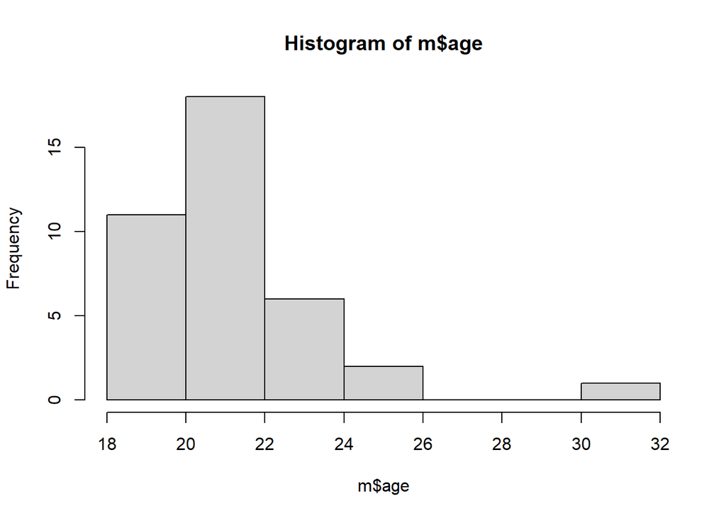

```r
hist(m$age)
```

## L1

36 whose only L1 is Italian. 1 person whose L1s are Italian and Norwegian. 1 person whose L1 is Romanian.

```r
table(m$L1)
```

```
##
##           Italian Italian;Norwegian          Romanian
##                36                 1                 1
```

## Previous acquaintance with partner?

One dyad knew each other a little bit from before. Both rated their acquaintance at the same level.

```r
table(m$preAcquaintance)
```

```
##
##  1  3
## 36  2
```

## How they felt during the first task

- Privacy: all ok
- Felt at ease: one person didn’t
- Conversation as a good way to get to know someone: 2 said no
- Is often in conversations like this: 21 yes, 17 no
- Friends would make questions like these: 18 yes, 20 no
- Friends think conversation is important to get to know someone: 36 yes, 2 no

```r
table(m$privacy)
```

```
##
##  Y
## 38
```

```r
table(m$atEase)
```

```
##
##  N  Y
##  1 37
```

```r
table(m$convMeet)
```

```
##
##  N  Y
##  2 36
```

```r
table(m$convHabit)
```

```
##
##  N  Y
## 17 21
```

```r
table(m$friendsQuestions)
```

```
##
##  N  Y
## 20 18
```

```r
table(m$convFriends)
```

```
##
##  N  Y
##  2 36
```

# Stats

## Manipulation Check

### Thermal Comfort

People found the room warmer after the interaction in the Close condition (p = 0.02, already accounting for the room temperature). Before the interaction, there was no condition difference, and the only significant predictor of thermal comfort/perception was the real room temperature.

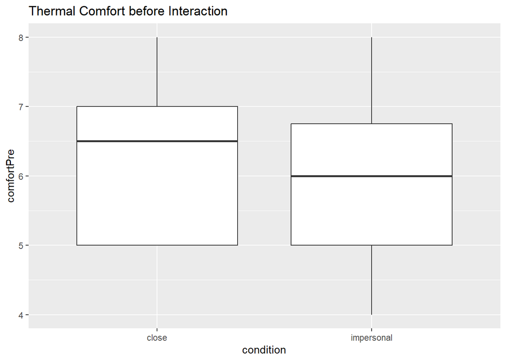

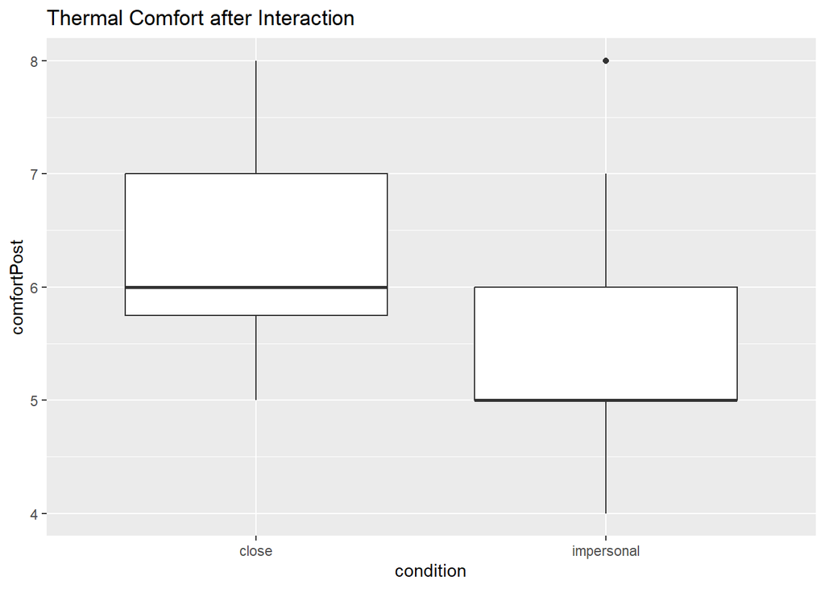

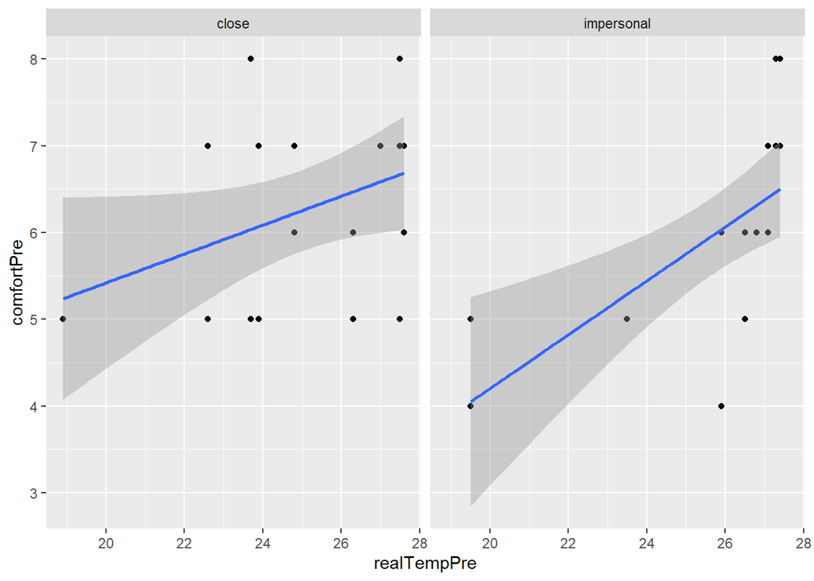

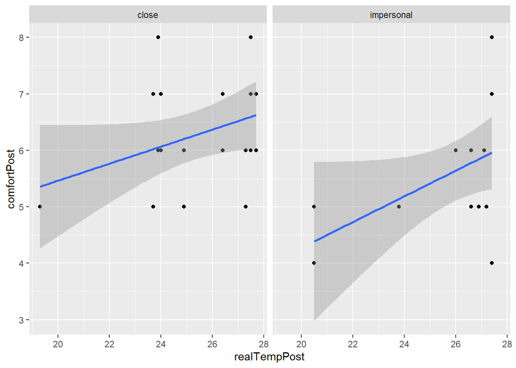

```r
summary(r <- lm(comfortPre ~ condition, m))
```

```
##
## Call:
## lm(formula = comfortPre ~ condition, data = m)
##
## Residuals:
##      Min       1Q   Median       3Q      Max
## -1.94444 -0.94444  0.05556  0.75000  2.05556
##
## Coefficients:
##                     Estimate Std. Error t value Pr(>|t|)
## (Intercept)           6.2500     0.2491  25.085   <2e-16 ***
## conditionimpersonal  -0.3056     0.3620  -0.844    0.404
## ---
## Signif. codes:  0 '***' 0.001 '**' 0.01 '*' 0.05 '.' 0.1 ' ' 1
##
## Residual standard error: 1.114 on 36 degrees of freedom
## Multiple R-squared:  0.01941,    Adjusted R-squared:  -0.007833
## F-statistic: 0.7124 on 1 and 36 DF,  p-value: 0.4042
```

```r
AIC(r)
```

```
## [1] 120.0053
```

```r
summary(r0 <- lm(comfortPre ~ realTempPre, m)) # preferred model!
```

```
##
## Call:
## lm(formula = comfortPre ~ realTempPre, data = m)
##
## Residuals:
##     Min      1Q  Median      3Q     Max
## -2.2404 -0.5883 -0.1207  0.4876  2.2383
##
## Coefficients:
##             Estimate Std. Error t value Pr(>|t|)
## (Intercept)  0.60495    1.54840   0.391  0.69833
## realTempPre  0.21758    0.06094   3.571  0.00103 **
## ---
## Signif. codes:  0 '***' 0.001 '**' 0.01 '*' 0.05 '.' 0.1 ' ' 1
##
## Residual standard error: 0.9669 on 36 degrees of freedom
## Multiple R-squared:  0.2615, Adjusted R-squared:  0.241
## F-statistic: 12.75 on 1 and 36 DF,  p-value: 0.001033
```

```r
AIC(r0)
```

```
## [1] 109.2294
```

```r
summary(r1 <- lm(comfortPre ~ realTempPre + condition, m))
```

```
##
## Call:
## lm(formula = comfortPre ~ realTempPre + condition, data = m)
##
## Residuals:
##      Min       1Q   Median       3Q      Max
## -2.01039 -0.52777 -0.07887  0.59804  2.04217
##
## Coefficients:
##                     Estimate Std. Error t value Pr(>|t|)
## (Intercept)           0.5480     1.5262   0.359 0.721700
## realTempPre           0.2283     0.0605   3.773 0.000599 ***
## conditionimpersonal  -0.4496     0.3119  -1.442 0.158317
## ---
## Signif. codes:  0 '***' 0.001 '**' 0.01 '*' 0.05 '.' 0.1 ' ' 1
##
## Residual standard error: 0.9528 on 35 degrees of freedom
## Multiple R-squared:  0.3029, Adjusted R-squared:  0.2631
## F-statistic: 7.605 on 2 and 35 DF,  p-value: 0.001809
```

```r
AIC(r1)
```

```
## [1] 109.0377
```

```r
summary(r <- lm(comfortPost ~ condition, m))
```

```
##
## Call:
## lm(formula = comfortPost ~ condition, data = m)
##
## Residuals:
##     Min      1Q  Median      3Q     Max
## -1.6111 -0.6111 -0.2500  0.7500  2.3889
##
## Coefficients:
##                     Estimate Std. Error t value Pr(>|t|)
## (Intercept)           6.2500     0.2358  26.507   <2e-16 ***
## conditionimpersonal  -0.6389     0.3426  -1.865   0.0704 .
## ---
## Signif. codes:  0 '***' 0.001 '**' 0.01 '*' 0.05 '.' 0.1 ' ' 1
##
## Residual standard error: 1.054 on 36 degrees of freedom
## Multiple R-squared:  0.0881, Adjusted R-squared:  0.06277
## F-statistic: 3.478 on 1 and 36 DF,  p-value: 0.07036
```

```r
AIC(r)
```

```
## [1] 115.8149
```

```r
summary(r0 <- lm(comfortPost ~ realTempPost, m))
```

```
##
## Call:
## lm(formula = comfortPost ~ realTempPost, data = m)
##
## Residuals:
##     Min      1Q  Median      3Q     Max
## -2.2463 -0.6703 -0.1023  0.7297  2.3137
##
## Coefficients:
##              Estimate Std. Error t value Pr(>|t|)
## (Intercept)   1.86246    1.80401   1.032    0.309
## realTempPost  0.15999    0.07035   2.274    0.029 *
## ---
## Signif. codes:  0 '***' 0.001 '**' 0.01 '*' 0.05 '.' 0.1 ' ' 1
##
## Residual standard error: 1.033 on 36 degrees of freedom
## Multiple R-squared:  0.1256, Adjusted R-squared:  0.1013
## F-statistic: 5.172 on 1 and 36 DF,  p-value: 0.02902
```

```r
AIC(r0)
```

```
## [1] 114.2183
```

```r
summary(r1 <- lm(comfortPost ~ realTempPost + condition, m)) # preferred model!
```

```
##
## Call:
## lm(formula = comfortPost ~ realTempPost + condition, data = m)
##
## Residuals:
##     Min      1Q  Median      3Q     Max
## -1.8881 -0.6921 -0.1005  0.3666  2.1119
##
## Coefficients:
##                     Estimate Std. Error t value Pr(>|t|)
## (Intercept)          1.66148    1.69946   0.978   0.3350
## realTempPost         0.18194    0.06683   2.722   0.0100 *
## conditionimpersonal -0.75856    0.31868  -2.380   0.0229 *
## ---
## Signif. codes:  0 '***' 0.001 '**' 0.01 '*' 0.05 '.' 0.1 ' ' 1
##
## Residual standard error: 0.9715 on 35 degrees of freedom
## Multiple R-squared:  0.2474, Adjusted R-squared:  0.2044
## F-statistic: 5.754 on 2 and 35 DF,  p-value: 0.006909
```

```r
AIC(r1)
```

```
## [1] 110.5166
```

#### Thermal comfort & questionnaire scores

Thermal comfort at the end of the experiment was not related to the participants’ perception of their partner (although all the non-significant effects are in the direction we would expect, i.e. warmer temperature perception positive with warmer social perception).

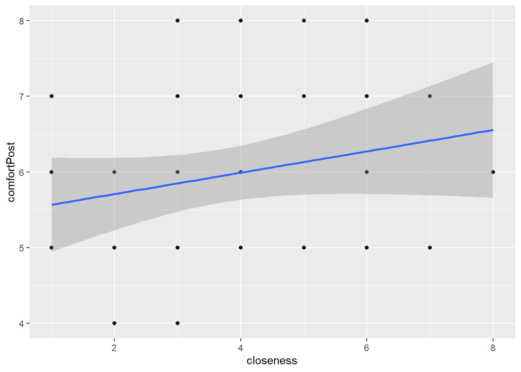

```r
ggplot(m, aes(closeness, comfortPost))+
  geom_point()+
  geom_smooth(method="lm")
```

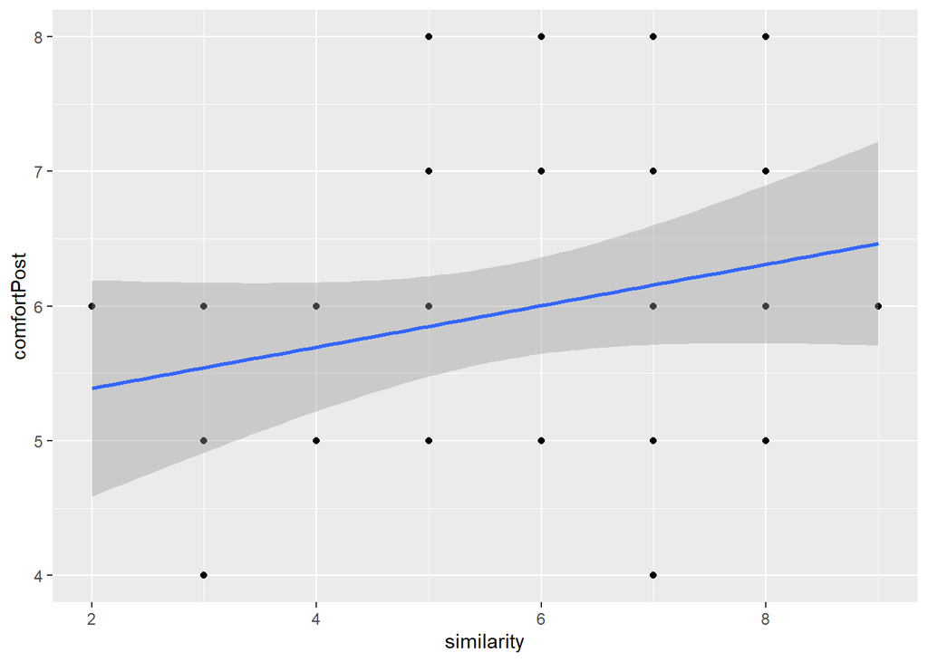

```r
ggplot(m, aes(similarity, comfortPost))+
  geom_point()+
  geom_smooth(method="lm")
```

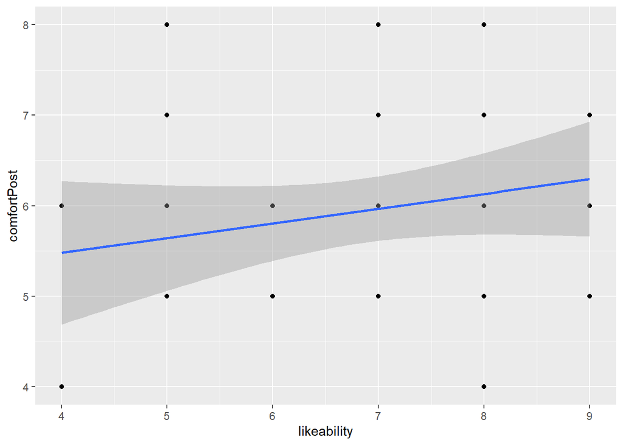

```r
ggplot(m, aes(likeability, comfortPost))+
  geom_point()+
  geom_smooth(method="lm")
```

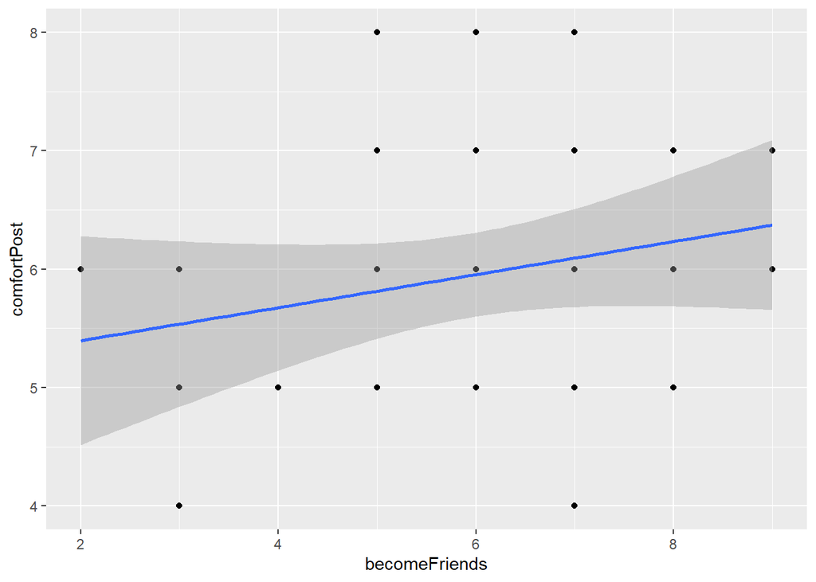

```r
ggplot(m, aes(becomeFriends, comfortPost))+
  geom_point()+
  geom_smooth(method="lm")
```

```r
summary(r <- lm(comfortPost ~ closeness, m))
```

```
##
## Call:
## lm(formula = comfortPost ~ closeness, data = m)
##
## Residuals:
##      Min       1Q   Median       3Q      Max
## -1.85085 -0.81558  0.07862  0.69068  2.14915
##
## Coefficients:
##             Estimate Std. Error t value Pr(>|t|)
## (Intercept)  5.42765    0.38703  14.024 3.69e-16 ***
## closeness    0.14107    0.09387   1.503    0.142
## ---
## Signif. codes:  0 '***' 0.001 '**' 0.01 '*' 0.05 '.' 0.1 ' ' 1
##
## Residual standard error: 1.071 on 36 degrees of freedom
## Multiple R-squared:  0.05903,    Adjusted R-squared:  0.03289
## F-statistic: 2.258 on 1 and 36 DF,  p-value: 0.1416
```

```r
summary(r <- lm(comfortPost ~ similarity, m))
```

```
##
## Call:
## lm(formula = comfortPost ~ similarity, data = m)
##
## Residuals:
##     Min      1Q  Median      3Q     Max
## -2.1577 -0.8119 -0.1577  0.6887  2.1497
##
## Coefficients:
##             Estimate Std. Error t value Pr(>|t|)
## (Intercept)   5.0819     0.5785   8.785 1.75e-10 ***
## similarity    0.1537     0.0980   1.568    0.126
## ---
## Signif. codes:  0 '***' 0.001 '**' 0.01 '*' 0.05 '.' 0.1 ' ' 1
##
## Residual standard error: 1.068 on 36 degrees of freedom
## Multiple R-squared:  0.06394,    Adjusted R-squared:  0.03794
## F-statistic: 2.459 on 1 and 36 DF,  p-value: 0.1256
```

```r
summary(r <- lm(comfortPost ~ likeability, m))
```

```
##
## Call:
## lm(formula = comfortPost ~ likeability, data = m)
##
## Residuals:
##      Min       1Q   Median       3Q      Max
## -2.13134 -0.80618  0.03124  0.70608  2.35640
##
## Coefficients:
##             Estimate Std. Error t value Pr(>|t|)
## (Intercept)   4.8307     0.8545   5.653 2.02e-06 ***
## likeability   0.1626     0.1218   1.335     0.19
## ---
## Signif. codes:  0 '***' 0.001 '**' 0.01 '*' 0.05 '.' 0.1 ' ' 1
##
## Residual standard error: 1.078 on 36 degrees of freedom
## Multiple R-squared:  0.04718,    Adjusted R-squared:  0.02071
## F-statistic: 1.782 on 1 and 36 DF,  p-value: 0.1902
```

```r
summary(r <- lm(comfortPost ~ becomeFriends, m))
```

```
##
## Call:
## lm(formula = comfortPost ~ becomeFriends, data = m)
##
## Residuals:
##      Min       1Q   Median       3Q      Max
## -2.09427 -0.81516 -0.09427  0.73128  2.18484
##
## Coefficients:
##               Estimate Std. Error t value Pr(>|t|)
## (Intercept)     5.1174     0.6245   8.194 9.53e-10 ***
## becomeFriends   0.1396     0.1008   1.384    0.175
## ---
## Signif. codes:  0 '***' 0.001 '**' 0.01 '*' 0.05 '.' 0.1 ' ' 1
##
## Residual standard error: 1.076 on 36 degrees of freedom
## Multiple R-squared:  0.05053,    Adjusted R-squared:  0.02416
## F-statistic: 1.916 on 1 and 36 DF,  p-value: 0.1748
```

### Temperature Guessing

No difference in temperature perception before and after interaction between conditions.

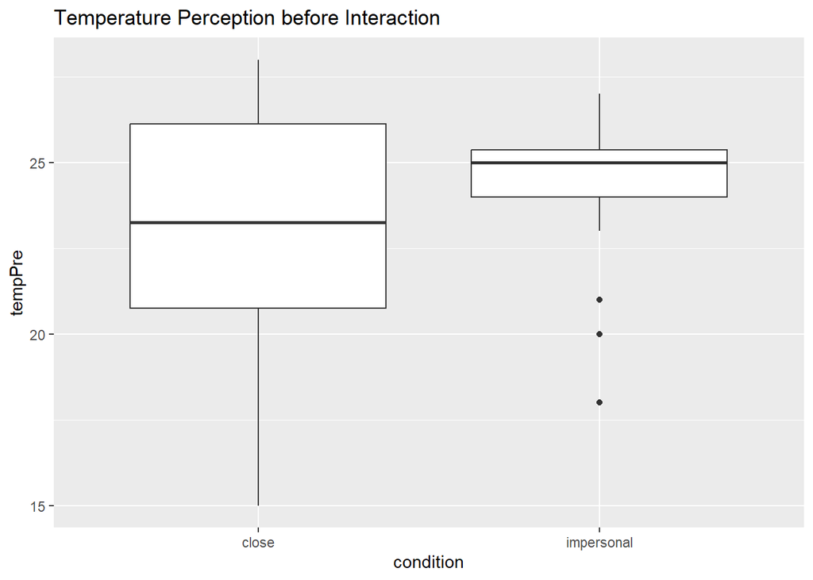

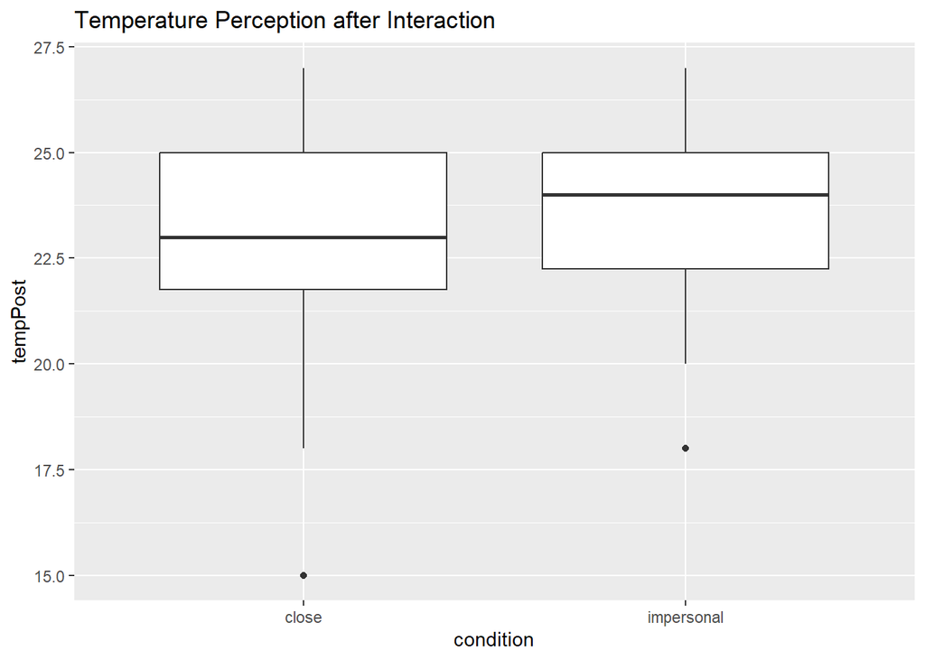

```r
summary(lm(tempPre ~ condition, m))
```

```
##
## Call:
## lm(formula = tempPre ~ condition, data = m)
##
## Residuals:
##    Min     1Q Median     3Q    Max
## -8.350 -1.350  0.750  1.725  4.650
##
## Coefficients:
##                     Estimate Std. Error t value Pr(>|t|)
## (Intercept)          23.3500     0.6616  35.292   <2e-16 ***
## conditionimpersonal   0.9000     0.9613   0.936    0.355
## ---
## Signif. codes:  0 '***' 0.001 '**' 0.01 '*' 0.05 '.' 0.1 ' ' 1
##
## Residual standard error: 2.959 on 36 degrees of freedom
## Multiple R-squared:  0.02377,    Adjusted R-squared:  -0.003349
## F-statistic: 0.8765 on 1 and 36 DF,  p-value: 0.3554
```

```r
summary(lm(tempPost ~ condition, m))
```

```
##
## Call:
## lm(formula = tempPost ~ condition, data = m)
##
## Residuals:
##     Min      1Q  Median      3Q     Max
## -7.9000 -1.2875  0.3417  2.0958  4.1000
##
## Coefficients:
##                     Estimate Std. Error t value Pr(>|t|)
## (Intercept)          22.9000     0.6191  36.992   <2e-16 ***
## conditionimpersonal   0.5167     0.8995   0.574    0.569
## ---
## Signif. codes:  0 '***' 0.001 '**' 0.01 '*' 0.05 '.' 0.1 ' ' 1
##
## Residual standard error: 2.768 on 36 degrees of freedom
## Multiple R-squared:  0.009082,   Adjusted R-squared:  -0.01844
## F-statistic:  0.33 on 1 and 36 DF,  p-value: 0.5693
```

### Closeness

People in the Close condition felt closer to their partner (p = 0.01).

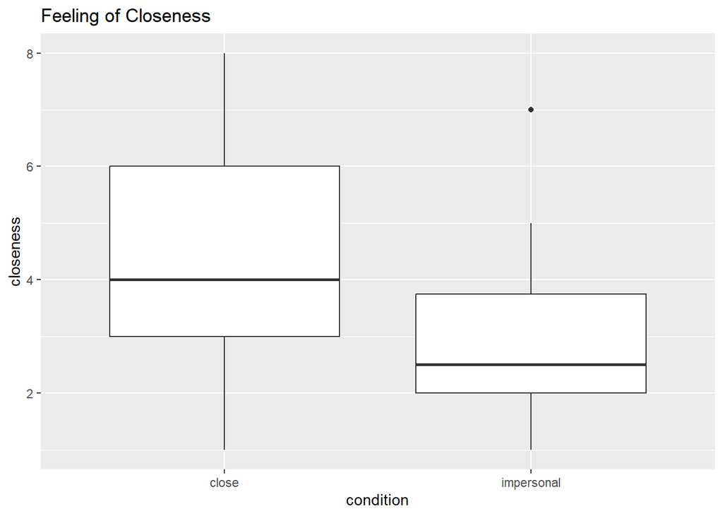

```r
summary(lm(closeness ~ condition, m))
```

```
##
## Call:
## lm(formula = closeness ~ condition, data = m)
##
## Residuals:
##    Min     1Q Median     3Q    Max
## -3.400 -1.400 -0.400  1.478  4.111
##
## Coefficients:
##                     Estimate Std. Error t value Pr(>|t|)
## (Intercept)           4.4000     0.3883  11.330 1.99e-13 ***
## conditionimpersonal  -1.5111     0.5642  -2.678   0.0111 *
## ---
## Signif. codes:  0 '***' 0.001 '**' 0.01 '*' 0.05 '.' 0.1 ' ' 1
##
## Residual standard error: 1.737 on 36 degrees of freedom
## Multiple R-squared:  0.1661, Adjusted R-squared:  0.143
## F-statistic: 7.173 on 1 and 36 DF,  p-value: 0.01108
```

#### Is people’s feeling of closeness reciprocal?

Not according to the regression (p = 0.16), even if the plot suggests that yes. Maybe we’d need more data.

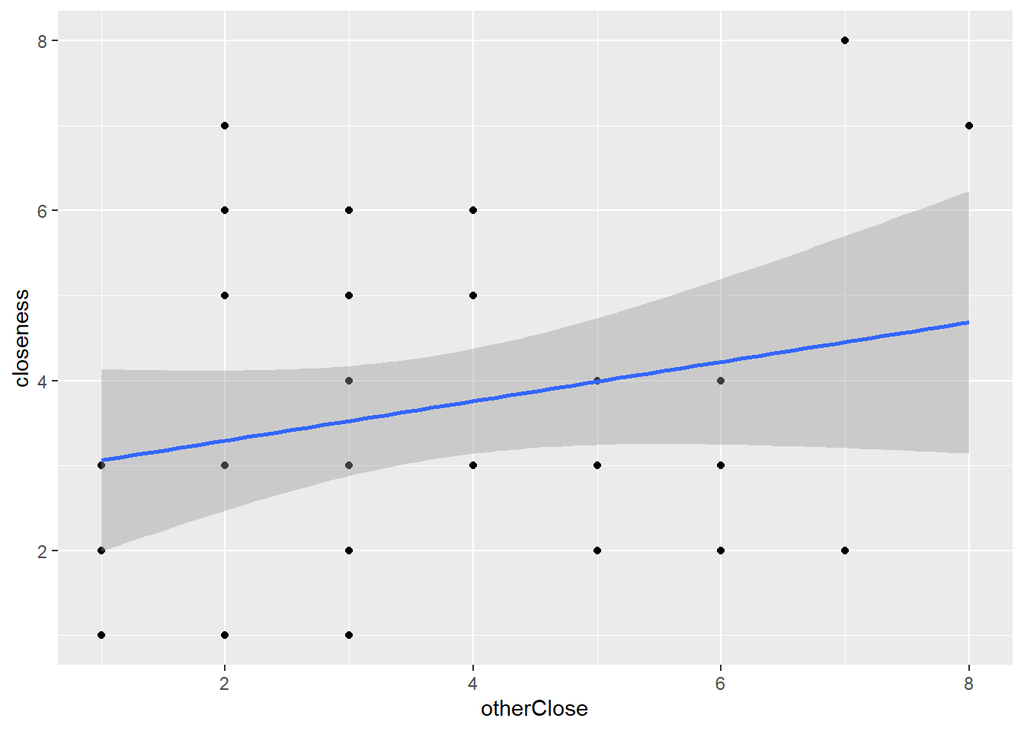

```r
ggplot(dat, aes(otherClose, closeness))+
  geom_point()+
  geom_smooth(method="lm")
```

```r
summary(lm(closeness ~ otherClose, dat))
```

```
##
## Call:
## lm(formula = closeness ~ otherClose, data = dat)
##
## Residuals:
##     Min      1Q  Median      3Q     Max
## -2.5255 -1.4495 -0.1415  1.4165  3.7065
##
## Coefficients:
##             Estimate Std. Error t value Pr(>|t|)
## (Intercept)   2.8294     0.6684   4.233 0.000152 ***
## otherClose    0.2320     0.1621   1.431 0.161017
## ---
## Signif. codes:  0 '***' 0.001 '**' 0.01 '*' 0.05 '.' 0.1 ' ' 1
##
## Residual standard error: 1.85 on 36 degrees of freedom
## Multiple R-squared:  0.05383,    Adjusted R-squared:  0.02755
## F-statistic: 2.048 on 1 and 36 DF,  p-value: 0.161
```

### Similarity

People in the Close condition didn’t feel more similar to their partner (p = 0.13), though the figure indicates a potential small effect.

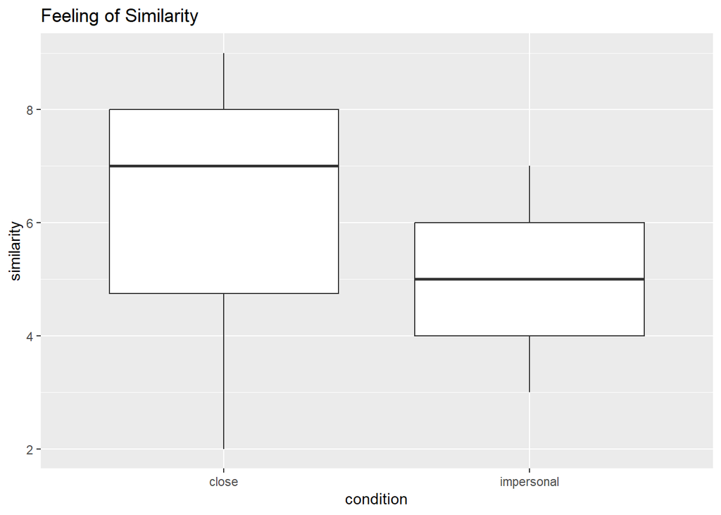

```r
summary(lm(similarity ~ condition, m))
```

```
##
## Call:
## lm(formula = similarity ~ condition, data = m)
##
## Residuals:
##     Min      1Q  Median      3Q     Max
## -4.0500 -1.1667  0.3917  1.6125  2.9500
##
## Coefficients:
##                     Estimate Std. Error t value Pr(>|t|)
## (Intercept)           6.0500     0.3934  15.377   <2e-16 ***
## conditionimpersonal  -0.8833     0.5716  -1.545    0.131
## ---
## Signif. codes:  0 '***' 0.001 '**' 0.01 '*' 0.05 '.' 0.1 ' ' 1
##
## Residual standard error: 1.759 on 36 degrees of freedom
## Multiple R-squared:  0.0622, Adjusted R-squared:  0.03615
## F-statistic: 2.388 on 1 and 36 DF,  p-value: 0.131
```

### Likeability

People in the Close condition liked their partner better (p = 0.015).

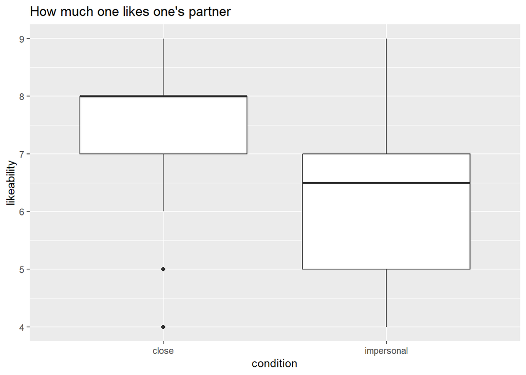

```r
summary(lm(likeability ~ condition, m))
```

```
##
## Call:
## lm(formula = likeability ~ condition, data = m)
##
## Residuals:
##     Min      1Q  Median      3Q     Max
## -3.4000 -1.2778  0.6000  0.7222  2.7222
##
## Coefficients:
##                     Estimate Std. Error t value Pr(>|t|)
## (Intercept)           7.4000     0.3037  24.366   <2e-16 ***
## conditionimpersonal  -1.1222     0.4413  -2.543   0.0154 *
## ---
## Signif. codes:  0 '***' 0.001 '**' 0.01 '*' 0.05 '.' 0.1 ' ' 1
##
## Residual standard error: 1.358 on 36 degrees of freedom
## Multiple R-squared:  0.1523, Adjusted R-squared:  0.1287
## F-statistic: 6.468 on 1 and 36 DF,  p-value: 0.01543
```

### Wish to Become Friends

People in the Close condition didn’t want more to be friends with their partner (p = 0.27).

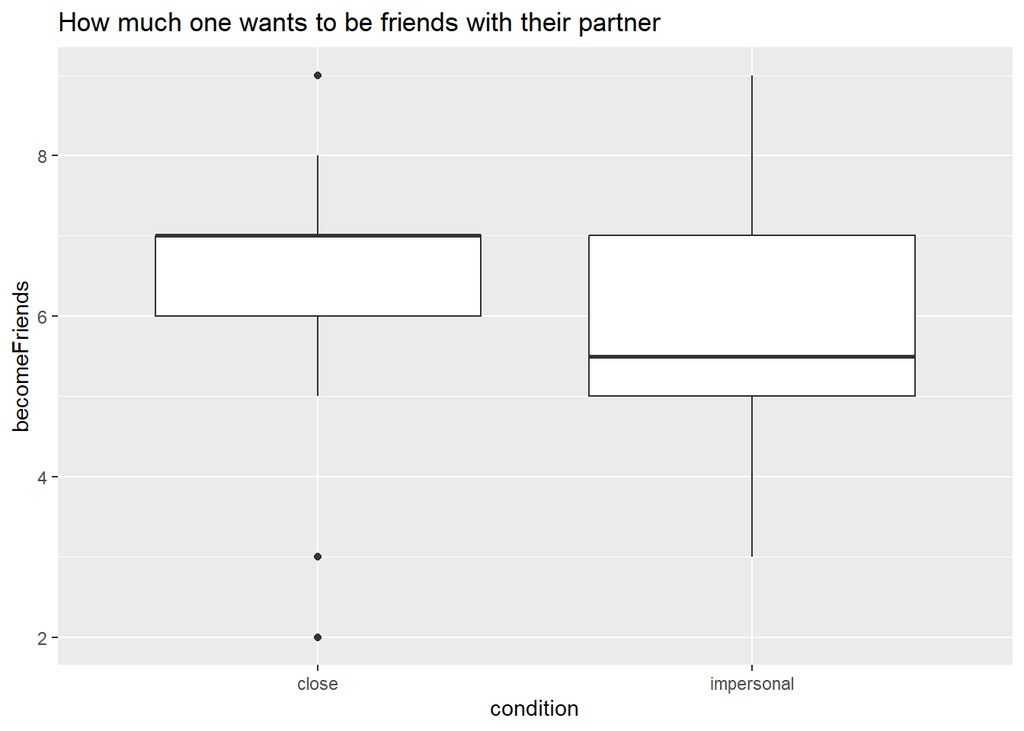

```r
summary(lm(becomeFriends ~ condition, m))
```

```
##
## Call:
## lm(formula = becomeFriends ~ condition, data = m)
##
## Residuals:
##     Min      1Q  Median      3Q     Max
## -4.2500 -0.6111  0.3889  1.3889  3.3889
##
## Coefficients:
##                     Estimate Std. Error t value Pr(>|t|)
## (Intercept)           6.2500     0.3909  15.988   <2e-16 ***
## conditionimpersonal  -0.6389     0.5680  -1.125    0.268
## ---
## Signif. codes:  0 '***' 0.001 '**' 0.01 '*' 0.05 '.' 0.1 ' ' 1
##
## Residual standard error: 1.748 on 36 degrees of freedom
## Multiple R-squared:  0.03395,    Adjusted R-squared:  0.007117
## F-statistic: 1.265 on 1 and 36 DF,  p-value: 0.2681
```

## Correlation between RCIT variables

There is clearly a large correlation between most of the variables. But if we wanted to identify the principal components to summarize/get the average of the questionnaire scores, it’s not clear what items should be allocated to which components.

```r
Hmisc::rcorr(as.matrix(m |> select(closeness, similarity, likeability, becomeFriends))) # to also see p values (all very low!)
```

```
##               closeness similarity likeability becomeFriends
## closeness          1.00       0.54        0.68          0.48
## similarity         0.54       1.00        0.73          0.68
## likeability        0.68       0.73        1.00          0.69
## becomeFriends      0.48       0.68        0.69          1.00
##
## n= 38
##
##
## P
##               closeness similarity likeability becomeFriends
## closeness               0.0004     0.0000      0.0023
## similarity    0.0004               0.0000      0.0000
## likeability   0.0000    0.0000                 0.0000
## becomeFriends 0.0023    0.0000     0.0000
```

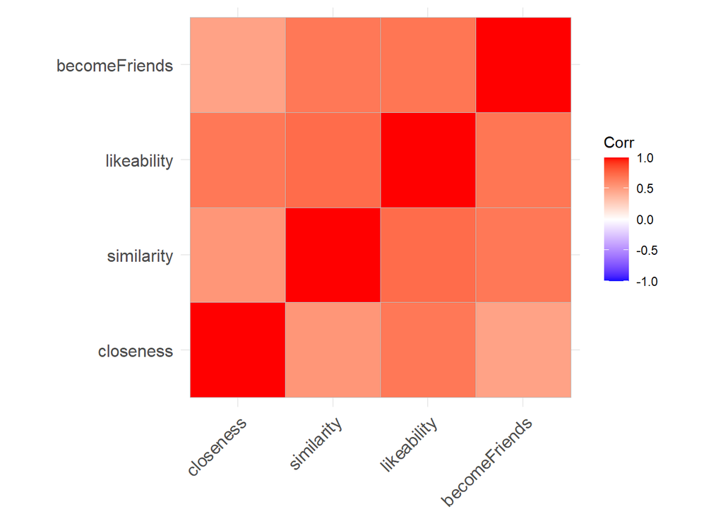

```r
# now do PCA (principal components analysis)

corM <- cor(m |> select(closeness, similarity, likeability, becomeFriends))
ggcorrplot::ggcorrplot(corM)
```

```r
summary(pc <- princomp(corM))
```

```
## Importance of components:
##                           Comp.1    Comp.2    Comp.3       Comp.4
## Standard deviation     0.2784904 0.1610789 0.1288216 3.370807e-09
## Proportion of Variance 0.6457785 0.2160430 0.1381785 9.460864e-17
## Cumulative Proportion  0.6457785 0.8618215 1.0000000 1.000000e+00
```

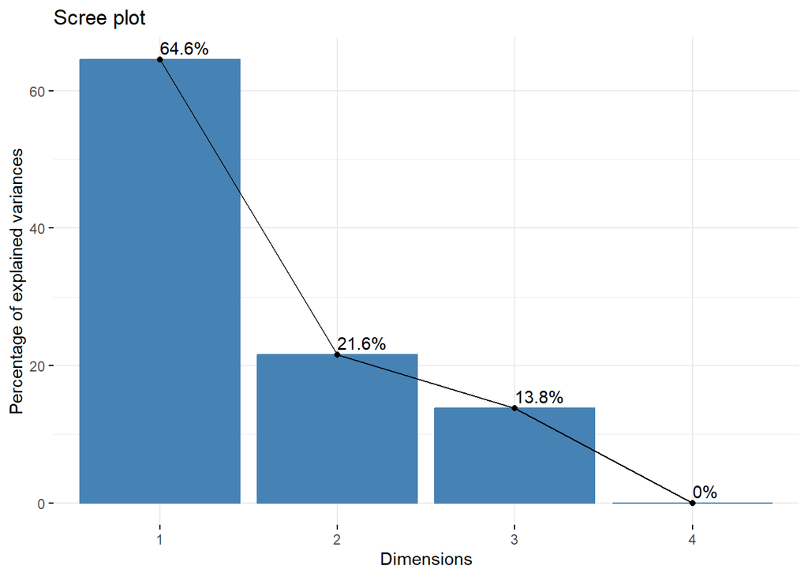

```r
factoextra::fviz_eig(pc, addlabels = TRUE)
```

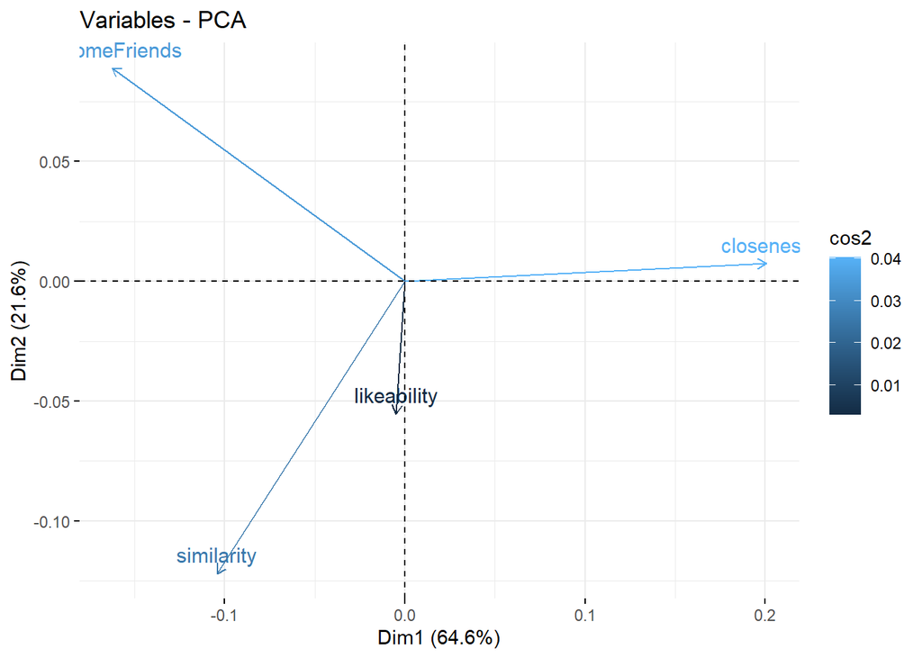

```r
factoextra::fviz_pca_var(pc, col.var = "cos2") # i guess this suggests there are 3 principal components
```

```r
pc$loadings[,1:3] # but the loadings don't really reflect those suggested dimensions...
```

```
##                    Comp.1      Comp.2      Comp.3
## closeness      0.72043239  0.04608885  0.02813063
## similarity    -0.37457082 -0.75733758  0.32126163
## likeability   -0.01749637 -0.34351770 -0.93563750
## becomeFriends -0.58341044  0.55345388 -0.14346461
```

```r
parameters::principal_components(m |> select(closeness, similarity, likeability, becomeFriends)) # and if we use another method, it suggests only 1 component
```

```
## # Loadings from Principal Component Analysis (no rotation)
##
## Variable      | PC1  | Complexity
## ---------------------------------
## closeness     | 0.78 |    1.00
## similarity    | 0.87 |    1.00
## likeability   | 0.91 |    1.00
## becomeFriends | 0.84 |    1.00
##
## The unique principal component accounted for 72.62% of the total variance of the original data.
```

## Personality Scores Affected Ratings?

For the analyses below: should we actually fit `BFI * condition`? Does it make more sense? But then again, do we have enough data points for this?

### Extraversion

No effects

```r
summary(lm(closeness ~ extraversion, m))
```

```
##
## Call:
## lm(formula = closeness ~ extraversion, data = m)
##
## Residuals:
##    Min     1Q Median     3Q    Max
## -3.084 -1.501 -0.485  1.231  3.853
##
## Coefficients:
##              Estimate Std. Error t value Pr(>|t|)
## (Intercept)    1.9399     1.8016   1.077    0.289
## extraversion   0.5045     0.5136   0.982    0.333
##
## Residual standard error: 1.877 on 36 degrees of freedom
## Multiple R-squared:  0.0261, Adjusted R-squared:  -0.0009486
## F-statistic: 0.9649 on 1 and 36 DF,  p-value: 0.3325
```

```r
summary(lm(similarity ~ extraversion, m))
```

```
##
## Call:
## lm(formula = similarity ~ extraversion, data = m)
##
## Residuals:
##    Min     1Q Median     3Q    Max
## -3.682 -1.541  0.299  1.403  3.092
##
## Coefficients:
##              Estimate Std. Error t value Pr(>|t|)
## (Intercept)    4.5891     1.7352   2.645    0.012 *
## extraversion   0.3015     0.4947   0.610    0.546
## ---
## Signif. codes:  0 '***' 0.001 '**' 0.01 '*' 0.05 '.' 0.1 ' ' 1
##
## Residual standard error: 1.808 on 36 degrees of freedom
## Multiple R-squared:  0.01022,    Adjusted R-squared:  -0.01728
## F-statistic: 0.3716 on 1 and 36 DF,  p-value: 0.546
```

```r
summary(lm(likeability ~ extraversion, m))
```

```
##
## Call:
## lm(formula = likeability ~ extraversion, data = m)
##
## Residuals:
##     Min      1Q  Median      3Q     Max
## -2.8077 -1.1373  0.1557  1.0733  2.4120
##
## Coefficients:
##              Estimate Std. Error t value Pr(>|t|)
## (Intercept)    5.8557     1.4057   4.166 0.000185 ***
## extraversion   0.2929     0.4007   0.731 0.469547
## ---
## Signif. codes:  0 '***' 0.001 '**' 0.01 '*' 0.05 '.' 0.1 ' ' 1
##
## Residual standard error: 1.464 on 36 degrees of freedom
## Multiple R-squared:  0.01462,    Adjusted R-squared:  -0.01275
## F-statistic: 0.5343 on 1 and 36 DF,  p-value: 0.4695
```

```r
summary(lm(becomeFriends ~ extraversion, m))
```

```
##
## Call:
## lm(formula = becomeFriends ~ extraversion, data = m)
##
## Residuals:
##     Min      1Q  Median      3Q     Max
## -3.8929 -1.0147  0.2492  1.1578  3.0259
##
## Coefficients:
##              Estimate Std. Error t value Pr(>|t|)
## (Intercept)    7.0699     1.6968   4.167 0.000185 ***
## extraversion  -0.3247     0.4837  -0.671 0.506367
## ---
## Signif. codes:  0 '***' 0.001 '**' 0.01 '*' 0.05 '.' 0.1 ' ' 1
##
## Residual standard error: 1.768 on 36 degrees of freedom
## Multiple R-squared:  0.01236,    Adjusted R-squared:  -0.01507
## F-statistic: 0.4505 on 1 and 36 DF,  p-value: 0.5064
```

### Openness

Openness scores were positively related to feeling of closeness (p = 0.02) and how people liked their partner (p = 0.005). The p value of feeling of similarity was 0.09 and for wanting to become friends, 0.06.

The significant effects here are on the same questionnaire items as the significant ones in the manipulation check (closeness and likeability). So we also make sure that the participants weren’t unevenly distributed across the conditions: there was no difference in openness scores between conditions (p > 0.14).

```r
summary(lm(closeness ~ openness, m))
```

```
##
## Call:
## lm(formula = closeness ~ openness, data = m)
##
## Residuals:
##     Min      1Q  Median      3Q     Max
## -3.0825 -1.3286 -0.3166  1.3043  4.4646
##
## Coefficients:
##             Estimate Std. Error t value Pr(>|t|)
## (Intercept)   0.7070     1.2792   0.553   0.5839
## openness      0.8439     0.3533   2.388   0.0223 *
## ---
## Signif. codes:  0 '***' 0.001 '**' 0.01 '*' 0.05 '.' 0.1 ' ' 1
##
## Residual standard error: 1.767 on 36 degrees of freedom
## Multiple R-squared:  0.1368, Adjusted R-squared:  0.1128
## F-statistic: 5.704 on 1 and 36 DF,  p-value: 0.0223
```

```r
summary(lm(similarity ~ openness, m))
```

```
##
## Call:
## lm(formula = similarity ~ openness, data = m)
##
## Residuals:
##     Min      1Q  Median      3Q     Max
## -3.4159 -1.3894 -0.1648  1.5605  3.1864
##
## Coefficients:
##             Estimate Std. Error t value Pr(>|t|)
## (Intercept)   3.5117     1.2643   2.777  0.00864 **
## openness      0.6009     0.3493   1.720  0.09394 .
## ---
## Signif. codes:  0 '***' 0.001 '**' 0.01 '*' 0.05 '.' 0.1 ' ' 1
##
## Residual standard error: 1.747 on 36 degrees of freedom
## Multiple R-squared:  0.07597,    Adjusted R-squared:  0.05031
## F-statistic:  2.96 on 1 and 36 DF,  p-value: 0.09394
```

```r
summary(lm(likeability ~ openness, m))
```

```
##
## Call:
## lm(formula = likeability ~ openness, data = m)
##
## Residuals:
##      Min       1Q   Median       3Q      Max
## -2.76716 -0.85398  0.02199  0.92897  2.68091
##
## Coefficients:
##             Estimate Std. Error t value Pr(>|t|)
## (Intercept)   4.0788     0.9554   4.269 0.000136 ***
## openness      0.7907     0.2639   2.996 0.004928 **
## ---
## Signif. codes:  0 '***' 0.001 '**' 0.01 '*' 0.05 '.' 0.1 ' ' 1
##
## Residual standard error: 1.32 on 36 degrees of freedom
## Multiple R-squared:  0.1996, Adjusted R-squared:  0.1773
## F-statistic: 8.976 on 1 and 36 DF,  p-value: 0.004928
```

```r
summary(lm(becomeFriends ~ openness, m))
```

```
##
## Call:
## lm(formula = becomeFriends ~ openness, data = m)
##
## Residuals:
##     Min      1Q  Median      3Q     Max
## -3.3782 -0.9266  0.1858  1.2639  2.5206
##
## Coefficients:
##             Estimate Std. Error t value Pr(>|t|)
## (Intercept)   3.6164     1.2244   2.954   0.0055 **
## openness      0.6607     0.3382   1.954   0.0586 .
## ---
## Signif. codes:  0 '***' 0.001 '**' 0.01 '*' 0.05 '.' 0.1 ' ' 1
##
## Residual standard error: 1.691 on 36 degrees of freedom
## Multiple R-squared:  0.09585,    Adjusted R-squared:  0.07073
## F-statistic: 3.816 on 1 and 36 DF,  p-value: 0.05856
```

```r
summary(lm(openness ~ condition, m))
```

```
##
## Call:
## lm(formula = openness ~ condition, data = m)
##
## Residuals:
##      Min       1Q   Median       3Q      Max
## -1.54500 -0.62931  0.00926  0.62167  1.50926
##
## Coefficients:
##                     Estimate Std. Error t value Pr(>|t|)
## (Intercept)           3.7117     0.1810  20.508   <2e-16 ***
## conditionimpersonal  -0.3876     0.2630  -1.474    0.149
## ---
## Signif. codes:  0 '***' 0.001 '**' 0.01 '*' 0.05 '.' 0.1 ' ' 1
##
## Residual standard error: 0.8094 on 36 degrees of freedom
## Multiple R-squared:  0.05691,    Adjusted R-squared:  0.03071
## F-statistic: 2.172 on 1 and 36 DF,  p-value: 0.1492
```

### Agreeableness

No effects

```r
summary(lm(closeness ~ agreeableness, m))
```

```
##
## Call:
## lm(formula = closeness ~ agreeableness, data = m)
##
## Residuals:
##     Min      1Q  Median      3Q     Max
## -2.7585 -1.6114 -0.6501  1.3499  4.2570
##
## Coefficients:
##               Estimate Std. Error t value Pr(>|t|)
## (Intercept)     3.3094     2.1241   1.558    0.128
## agreeableness   0.1084     0.6079   0.178    0.859
##
## Residual standard error: 1.901 on 36 degrees of freedom
## Multiple R-squared:  0.0008826,  Adjusted R-squared:  -0.02687
## F-statistic: 0.0318 on 1 and 36 DF,  p-value: 0.8595
```

```r
summary(lm(similarity ~ agreeableness, m))
```

```
##
## Call:
## lm(formula = similarity ~ agreeableness, data = m)
##
## Residuals:
##     Min      1Q  Median      3Q     Max
## -4.0133 -1.0850  0.2882  1.4138  2.9867
##
## Coefficients:
##               Estimate Std. Error t value Pr(>|t|)
## (Intercept)     3.1995     1.9884   1.609    0.116
## agreeableness   0.7034     0.5690   1.236    0.224
##
## Residual standard error: 1.78 on 36 degrees of freedom
## Multiple R-squared:  0.04072,    Adjusted R-squared:  0.01407
## F-statistic: 1.528 on 1 and 36 DF,  p-value: 0.2244
```

```r
summary(lm(likeability ~ agreeableness, m))
```

```
##
## Call:
## lm(formula = likeability ~ agreeableness, data = m)
##
## Residuals:
##     Min      1Q  Median      3Q     Max
## -3.3461 -1.1002  0.0755  1.1809  2.4268
##
## Coefficients:
##               Estimate Std. Error t value Pr(>|t|)
## (Intercept)     5.1678     1.6233   3.184    0.003 **
## agreeableness   0.4919     0.4645   1.059    0.297
## ---
## Signif. codes:  0 '***' 0.001 '**' 0.01 '*' 0.05 '.' 0.1 ' ' 1
##
## Residual standard error: 1.453 on 36 degrees of freedom
## Multiple R-squared:  0.03021,    Adjusted R-squared:  0.003267
## F-statistic: 1.121 on 1 and 36 DF,  p-value: 0.2967
```

```r
summary(lm(becomeFriends ~ agreeableness, m))
```

```
##
## Call:
## lm(formula = becomeFriends ~ agreeableness, data = m)
##
## Residuals:
##     Min      1Q  Median      3Q     Max
## -3.9268 -0.9593  0.0624  1.0570  3.0570
##
## Coefficients:
##               Estimate Std. Error t value Pr(>|t|)
## (Intercept)    6.07849    1.98735   3.059  0.00418 **
## agreeableness -0.03793    0.56872  -0.067  0.94720
## ---
## Signif. codes:  0 '***' 0.001 '**' 0.01 '*' 0.05 '.' 0.1 ' ' 1
##
## Residual standard error: 1.779 on 36 degrees of freedom
## Multiple R-squared:  0.0001235,  Adjusted R-squared:  -0.02765
## F-statistic: 0.004447 on 1 and 36 DF,  p-value: 0.9472
```

### Conscientiousness

No effects

```r
summary(lm(closeness ~ conscientiousness, m))
```

```
##
## Call:
## lm(formula = closeness ~ conscientiousness, data = m)
##
## Residuals:
##     Min      1Q  Median      3Q     Max
## -3.0851 -1.4234 -0.5557  1.2384  4.1502
##
## Coefficients:
##                   Estimate Std. Error t value Pr(>|t|)
## (Intercept)         1.5560     2.1799   0.714    0.480
## conscientiousness   0.5293     0.5369   0.986    0.331
##
## Residual standard error: 1.877 on 36 degrees of freedom
## Multiple R-squared:  0.02629,    Adjusted R-squared:  -0.0007539
## F-statistic: 0.9721 on 1 and 36 DF,  p-value: 0.3307
```

```r
summary(lm(similarity ~ conscientiousness, m))
```

```
##
## Call:
## lm(formula = similarity ~ conscientiousness, data = m)
##
## Residuals:
##     Min      1Q  Median      3Q     Max
## -3.7556 -1.6015  0.0463  1.4206  3.2444
##
## Coefficients:
##                   Estimate Std. Error t value Pr(>|t|)
## (Intercept)         4.0383     2.0933   1.929   0.0616 .
## conscientiousness   0.3963     0.5156   0.769   0.4471
## ---
## Signif. codes:  0 '***' 0.001 '**' 0.01 '*' 0.05 '.' 0.1 ' ' 1
##
## Residual standard error: 1.802 on 36 degrees of freedom
## Multiple R-squared:  0.01615,    Adjusted R-squared:  -0.01118
## F-statistic: 0.5908 on 1 and 36 DF,  p-value: 0.4471
```

```r
summary(lm(likeability ~ conscientiousness, m))
```

```
##
## Call:
## lm(formula = likeability ~ conscientiousness, data = m)
##
## Residuals:
##    Min     1Q Median     3Q    Max
## -2.634 -1.076  0.182  1.085  2.366
##
## Coefficients:
##                   Estimate Std. Error t value Pr(>|t|)
## (Intercept)         4.2024     1.6537   2.541   0.0155 *
## conscientiousness   0.6631     0.4073   1.628   0.1122
## ---
## Signif. codes:  0 '***' 0.001 '**' 0.01 '*' 0.05 '.' 0.1 ' ' 1
##
## Residual standard error: 1.424 on 36 degrees of freedom
## Multiple R-squared:  0.06858,    Adjusted R-squared:  0.04271
## F-statistic: 2.651 on 1 and 36 DF,  p-value: 0.1122
```

```r
summary(lm(becomeFriends ~ conscientiousness, m))
```

```
##
## Call:
## lm(formula = becomeFriends ~ conscientiousness, data = m)
##
## Residuals:
##     Min      1Q  Median      3Q     Max
## -3.9769 -0.9638  0.0808  1.0650  2.9917
##
## Coefficients:
##                   Estimate Std. Error t value Pr(>|t|)
## (Intercept)        5.56829    2.06507   2.696   0.0106 *
## conscientiousness  0.09429    0.50861   0.185   0.8540
## ---
## Signif. codes:  0 '***' 0.001 '**' 0.01 '*' 0.05 '.' 0.1 ' ' 1
##
## Residual standard error: 1.778 on 36 degrees of freedom
## Multiple R-squared:  0.0009537,  Adjusted R-squared:  -0.0268
## F-statistic: 0.03437 on 1 and 36 DF,  p-value: 0.854
```

### Neuroticism

No effects

```r
summary(lm(closeness ~ neuroticism, m))
```

```
##
## Call:
## lm(formula = closeness ~ neuroticism, data = m)
##
## Residuals:
##     Min      1Q  Median      3Q     Max
## -2.7009 -1.4018 -0.1731  1.5103  3.8621
##
## Coefficients:
##             Estimate Std. Error t value Pr(>|t|)
## (Intercept)    5.460      1.350   4.046 0.000264 ***
## neuroticism   -0.563      0.417  -1.350 0.185431
## ---
## Signif. codes:  0 '***' 0.001 '**' 0.01 '*' 0.05 '.' 0.1 ' ' 1
##
## Residual standard error: 1.855 on 36 degrees of freedom
## Multiple R-squared:  0.04819,    Adjusted R-squared:  0.02175
## F-statistic: 1.823 on 1 and 36 DF,  p-value: 0.1854
```

```r
summary(lm(similarity ~ neuroticism, m))
```

```
##
## Call:
## lm(formula = similarity ~ neuroticism, data = m)
##
## Residuals:
##     Min      1Q  Median      3Q     Max
## -3.6171 -1.6129  0.3352  1.3743  3.3999
##
## Coefficients:
##             Estimate Std. Error t value Pr(>|t|)
## (Intercept)  5.54561    1.32146   4.197 0.000169 ***
## neuroticism  0.02725    0.40835   0.067 0.947158
## ---
## Signif. codes:  0 '***' 0.001 '**' 0.01 '*' 0.05 '.' 0.1 ' ' 1
##
## Residual standard error: 1.817 on 36 degrees of freedom
## Multiple R-squared:  0.0001237,  Adjusted R-squared:  -0.02765
## F-statistic: 0.004454 on 1 and 36 DF,  p-value: 0.9472
```

```r
summary(lm(likeability ~ neuroticism, m))
```

```
##
## Call:
## lm(formula = likeability ~ neuroticism, data = m)
##
## Residuals:
##     Min      1Q  Median      3Q     Max
## -2.8702 -0.8756  0.1320  1.1323  2.1427
##
## Coefficients:
##             Estimate Std. Error t value Pr(>|t|)
## (Intercept)  6.90459    1.07297   6.435 1.83e-07 ***
## neuroticism -0.01147    0.33156  -0.035    0.973
## ---
## Signif. codes:  0 '***' 0.001 '**' 0.01 '*' 0.05 '.' 0.1 ' ' 1
##
## Residual standard error: 1.475 on 36 degrees of freedom
## Multiple R-squared:  3.322e-05,  Adjusted R-squared:  -0.02774
## F-statistic: 0.001196 on 1 and 36 DF,  p-value: 0.9726
```

```r
summary(lm(becomeFriends ~ neuroticism, m))
```

```
##
## Call:
## lm(formula = becomeFriends ~ neuroticism, data = m)
##
## Residuals:
##     Min      1Q  Median      3Q     Max
## -3.9725 -0.9428  0.0750  1.0705  3.0988
##
## Coefficients:
##             Estimate Std. Error t value Pr(>|t|)
## (Intercept)  6.09730    1.29349   4.714 3.59e-05 ***
## neuroticism -0.04753    0.39970  -0.119    0.906
## ---
## Signif. codes:  0 '***' 0.001 '**' 0.01 '*' 0.05 '.' 0.1 ' ' 1
##
## Residual standard error: 1.778 on 36 degrees of freedom
## Multiple R-squared:  0.0003926,  Adjusted R-squared:  -0.02737
## F-statistic: 0.01414 on 1 and 36 DF,  p-value: 0.906
```